# Instituto Internacional de Aguascalientes

## Maestría en Inteligencia Artificial para la Transformación Digital

### Programa: Aprendizaje Inteligente

## Práctica: Análisis, implementación y prueba de modelos de aprendizaje no supervisado K-means y PCA aplicados al dataset energético de Our World in Data

**Alumno:** Antonio Nicolás Toro González  
**Tutor:** Dr. Francisco Javier Luna Rosas

**Ciudad de México, julio de 2026**

## Repositorios y URL

**Repositorio GitHub:**  
https://github.com/antoniot73/ml_no_supervisado_owid_energy

**URL Binder:**  
https://mybinder.org/v2/gh/antoniot73/ml_no_supervisado_owid_energy/main?filepath=notebooks/practica_no_supervisado_owid_energy.ipynb

**GitHub Page:**  
https://antoniot73.github.io/ml_no_supervisado_owid_energy/notebooks/practica_no_supervisado_owid_energy.html

**Dataset utilizado:**  
https://github.com/owid/energy-data

## 1. Marco teórico y analítico

### 1.1 Diferencia entre aprendizaje supervisado y no supervisado

En el aprendizaje supervisado cada observación contiene variables de entrada $X$ y una respuesta conocida $y$. El modelo estima una función orientada a predecir una clase o un valor:

$$ \widehat{y}=f(X) $$

En el aprendizaje no supervisado no existe una etiqueta objetivo. El análisis se concentra en descubrir estructuras internas: grupos de observaciones semejantes, relaciones entre variables o representaciones de menor dimensión. Por ello, la evaluación no se basa en exactitud frente a una respuesta conocida, sino en criterios internos como cohesión, separación, varianza explicada, estabilidad e interpretación del resultado.

### 1.2 Definición de aprendizaje no supervisado

Sea un conjunto de $n$ observaciones:

$$ X=\{x_1,x_2,\ldots,x_n\} $$

donde cada observación $x_i$ contiene $p$ características. Un algoritmo no supervisado busca una estructura:

$$ S=g(X) $$

sin disponer de una variable objetivo. Los patrones obtenidos dependen de la escala, la distribución de las variables, la métrica de distancia y los hiperparámetros. En esta práctica se trabajan exclusivamente dos modelos complementarios: **K-means**, orientado al agrupamiento, y **PCA**, orientado a la reducción de dimensionalidad.

### 1.3 Modelo K-means

K-means divide las observaciones en $k$ clústeres mutuamente excluyentes. Cada grupo se representa mediante un centroide $\mu_j$, calculado como la media vectorial de las observaciones asignadas. El algoritmo minimiza la suma de cuadrados dentro de los grupos:

$$ J=\sum_{j=1}^{k}\sum_{x_i\in C_j}\left\lVert x_i-\mu_j\right\rVert^2 $$

El procedimiento alterna dos pasos: asignar cada observación al centroide más cercano y recalcular los centroides. Estos pasos continúan hasta que las asignaciones dejan de cambiar o se alcanza el límite de iteraciones.

La estandarización es necesaria cuando las variables tienen escalas diferentes, porque K-means utiliza distancias euclidianas. La selección de $k$ se apoya en la inercia y el coeficiente de silueta. Una silueta mayor indica, en términos generales, que las observaciones están mejor cohesionadas dentro de su grupo y más separadas de los grupos vecinos. Sus principales limitaciones son la sensibilidad a valores atípicos, a la inicialización y a grupos con formas no esféricas.

### 1.4 Modelo PCA

El Análisis de Componentes Principales transforma variables correlacionadas en componentes ortogonales. Cada componente es una combinación lineal de las variables originales:

$$ Z_j=a_{j1}X_1+a_{j2}X_2+\cdots+a_{jp}X_p $$

La primera componente captura la mayor varianza posible; la segunda captura la mayor varianza restante y es ortogonal a la primera. La proporción explicada por la componente $j$ se expresa como:

$$ R_j=\frac{\lambda_j}{\sum_{i=1}^{p}\lambda_i} $$

donde $\lambda_j$ es el autovalor asociado. PCA no forma clústeres: reduce redundancia, facilita la visualización y permite identificar qué variables explican las principales diferencias entre observaciones. Las cargas indican la contribución de cada variable a cada componente. Sus limitaciones incluyen sensibilidad a la escala y a valores atípicos, además de que solo representa relaciones lineales.

### 1.5 Uso simplificado de los archivos del dataset

La práctica utiliza dos archivos que cumplen funciones diferentes y se vinculan por el nombre de cada variable:

| Archivo | Contenido | Uso en la práctica |
| --- | --- | --- |
| `owid-energy-data.csv` | Observaciones de países y años con indicadores energéticos. | Proporciona los valores numéricos que procesan K-means y PCA. |
| `owid-energy-codebook.csv` | Diccionario con título, descripción, unidad y fuente de cada columna. | Permite comprobar qué significa cada variable y documentar su procedencia. |

La relación se establece de la siguiente manera:

$$ \text{codebook.column} \longleftrightarrow \text{nombre de columna en energy-data} $$

El flujo simplificado es:

$$ \text{data.csv} \rightarrow \text{selección de países de 2022} \rightarrow \text{variables energéticas} \rightarrow \text{K-means y PCA} $$

$$ \text{codebook.csv} \rightarrow \text{definición, unidad y fuente de las variables} $$

Se utiliza 2022 para comparar todos los países en un mismo momento. Así, cada fila analítica representa un país y no se mezclan varios años del mismo país como si fueran observaciones equivalentes. K-means y PCA reciben copias separadas de esa misma muestra transversal.

### 1.6 Criterios de prueba

Para **K-means** se evalúan valores $k=2,\ldots,8$ mediante:

- inercia;
- coeficiente de silueta;
- perfiles medios de los clústeres;
- distribución de países por grupo.

Para **PCA** se evalúan:

- varianza explicada individual;
- varianza acumulada;
- número de componentes requerido para alcanzar al menos 80%;
- cargas de las variables;
- proyección de países en las dos primeras componentes.

Los resultados son descriptivos y no implican causalidad.

## 2. Motivación de la práctica

El propósito de esta práctica es comprender, mediante una implementación reproducible, cómo dos modelos de aprendizaje no supervisado permiten analizar y resumir los perfiles energéticos de distintos países. K-means identifica grupos de países con patrones semejantes de consumo de energía por habitante, intensidad energética y composición de sus fuentes energéticas, lo que permite reconocer perfiles comunes y comparar las características que distinguen a cada clúster.

Por su parte, PCA transforma las variables originales en un conjunto menor de componentes principales e identifica qué combinaciones de indicadores explican la mayor parte de las diferencias observadas entre los países en términos de consumo energético, intensidad energética y composición de sus fuentes de energía.

En esta práctica, la intensidad energética corresponde al consumo de energía primaria por unidad de producto interno bruto y se expresa en kilovatios-hora por dólar internacional.

## 3. Planteamiento del problema

**Pregunta de investigación:** ¿qué perfiles energéticos pueden identificarse entre los países y cuáles variables explican las principales diferencias de sus sistemas energéticos?

La pregunta se divide en dos componentes:

1. **Identificación de perfiles:** determinar si los países pueden agruparse según su consumo de energía por habitante, intensidad energética, demanda eléctrica y composición de sus fuentes.
2. **Explicación de diferencias:** identificar qué combinaciones de variables explican la mayor parte de la variación observada entre los sistemas energéticos nacionales.

Cada país del año 2022 se representa mediante diez indicadores. Los dos modelos se ejecutan por separado sobre copias independientes del dataset analítico:

$$ \text{Dataset K-means}\rightarrow\text{escalamiento K-means}\rightarrow\text{agrupamiento} $$

$$ \text{Dataset PCA}\rightarrow\text{escalamiento PCA}\rightarrow\text{componentes} $$

K-means responde principalmente **qué países presentan perfiles semejantes**. PCA responde **qué dimensiones energéticas explican esas semejanzas y diferencias**.

## 4. Implementación en Python

El pipeline sigue la secuencia:

$$ \text{carga}\rightarrow\text{validación}\rightarrow\text{selección}\rightarrow\text{modelado}\rightarrow\text{evaluación}\rightarrow\text{reporte} $$

| Biblioteca | Uso |
| --- | --- |
| pandas | carga, selección y tablas |
| NumPy | matrices y validación numérica |
| scikit-learn | StandardScaler, KMeans, PCA y silueta |
| Matplotlib | visualizaciones |
| pathlib | rutas reproducibles |
| logging | trazabilidad de ejecución |

```python
# Configuración general del proyecto, rutas, semilla y logging.
from __future__ import annotations

import logging
import sys
from pathlib import Path

import pandas as pd
from IPython.display import HTML, Image, display

RANDOM_STATE = 42
YEAR = 2022

NOTEBOOK_DIR = Path.cwd()
PROJECT_ROOT = NOTEBOOK_DIR.parent if NOTEBOOK_DIR.name == "notebooks" else NOTEBOOK_DIR
SRC_DIR = PROJECT_ROOT / "src"
DATA_PATH = PROJECT_ROOT / "data" / "owid-energy-data.csv"
CODEBOOK_PATH = PROJECT_ROOT / "data" / "owid-energy-codebook.csv"
GRAPH_DIR = PROJECT_ROOT / "outputs" / "graficas"
TABLE_DIR = PROJECT_ROOT / "outputs" / "tablas"

GRAPH_DIR.mkdir(parents=True, exist_ok=True)
TABLE_DIR.mkdir(parents=True, exist_ok=True)

if str(SRC_DIR) not in sys.path:
    sys.path.insert(0, str(SRC_DIR))

class RelativePathFilter(logging.Filter):
    """Convierte rutas absolutas del proyecto en rutas relativas."""

    def filter(self, record: logging.LogRecord) -> bool:
        """Sanitiza los argumentos del mensaje antes de imprimirlos."""
        if not record.args:
            return True

        project_root = PROJECT_ROOT.resolve()
        sanitized_args = []

        for argument in record.args:
            try:
                argument_path = Path(argument).resolve()
                relative_path = argument_path.relative_to(project_root)
                sanitized_args.append(str(relative_path))
            except (TypeError, ValueError, OSError):
                sanitized_args.append(argument)

        record.args = tuple(sanitized_args)
        return True


logging.basicConfig(
    level=logging.INFO,
    format="%(asctime)s | %(levelname)s | %(name)s | %(message)s",
)

for handler in logging.getLogger().handlers:
    handler.addFilter(RelativePathFilter())

print("Configuración del proyecto: OK")
print(f"Dataset de observaciones: {DATA_PATH.relative_to(PROJECT_ROOT)}")
print(f"Diccionario de variables: {CODEBOOK_PATH.relative_to(PROJECT_ROOT)}")
print(f"Directorio de gráficas: {GRAPH_DIR.relative_to(PROJECT_ROOT)}")
print(f"Directorio de tablas: {TABLE_DIR.relative_to(PROJECT_ROOT)}")







def display_scrollable_dataframe(
    df_input: pd.DataFrame,
    height_px: int = 430,
    title: str = "Dataset completo",
    min_width_px: int = 760,
) -> None:
    """Muestra todos los registros dentro de una ventana con scrolling real.

    Args:
        df_input: DataFrame completo que se desea visualizar.
        height_px: Altura visible del contenedor.
        title: Título mostrado encima de la tabla.
        min_width_px: Ancho mínimo de la tabla.

    Raises:
        TypeError: Si df_input no es un DataFrame.
        ValueError: Si las dimensiones no son positivas.
    """
    if not isinstance(df_input, pd.DataFrame):
        raise TypeError("df_input debe ser un pandas DataFrame.")

    if height_px <= 0 or min_width_px <= 0:
        raise ValueError("height_px y min_width_px deben ser positivos.")

    df_display = df_input.copy()

    if "registro" not in df_display.columns:
        df_display.insert(0, "registro", range(1, len(df_display) + 1))

    total_registros = len(df_display)
    total_columnas = len(df_display.columns) - 1
    html_table = df_display.to_html(index=False, border=0, escape=True)

    html_scroll = f"""
    <div style="
        width: 100%;
        margin: 10px 0 22px 0;
        font-family: Arial, sans-serif;
    ">
        <h4 style="margin: 0 0 8px 0;">{title}</h4>

        <div style="
            display: flex;
            justify-content: space-between;
            align-items: center;
            gap: 12px;
            flex-wrap: wrap;
            margin-bottom: 8px;
            padding: 8px 10px;
            border: 1px solid #b8c2cc;
            border-radius: 6px;
            background: #eef4fb;
            color: #111111;
            font-size: 13px;
            font-weight: 700;
        ">
            <span>{total_registros} registros completos</span>
            <span>{total_columnas} columnas</span>
            <span>Use las barras vertical y horizontal para recorrer la tabla</span>
        </div>

        <div class="responsive-table-wrapper" style="
            --table-min-width: {min_width_px}px;
            display: block;
            width: 100%;
            max-width: 100%;
            height: {height_px}px;
            min-height: {height_px}px;
            max-height: {height_px}px;
            overflow-x: scroll;
            overflow-y: scroll;
            scrollbar-gutter: stable both-edges;
            border: 1px solid #b8c2cc;
            border-radius: 6px;
            background: #ffffff;
            box-sizing: border-box;
            -webkit-overflow-scrolling: touch;
        ">
            <style>
                .responsive-table-wrapper table {{
                    border-collapse: collapse !important;
                    width: max-content !important;
                    min-width: var(--table-min-width) !important;
                    max-width: none !important;
                    table-layout: auto !important;
                    font-family: Arial, sans-serif !important;
                    font-size: 13px !important;
                    color: #111111 !important;
                    background: #ffffff !important;
                    margin: 0 !important;
                }}

                .responsive-table-wrapper thead th {{
                    position: sticky !important;
                    top: 0 !important;
                    z-index: 4 !important;
                    padding: 9px 10px !important;
                    border: 1px solid #b8c2cc !important;
                    background: #e8eef5 !important;
                    color: #000000 !important;
                    font-weight: 700 !important;
                    text-align: center !important;
                    white-space: nowrap !important;
                }}

                .responsive-table-wrapper tbody td {{
                    height: 30px !important;
                    padding: 7px 9px !important;
                    border: 1px solid #d9dee5 !important;
                    color: #111111 !important;
                    text-align: center !important;
                    vertical-align: middle !important;
                    white-space: nowrap !important;
                }}

                .responsive-table-wrapper tbody tr:nth-child(even) td {{
                    background: #f3f6fa !important;
                }}

                .responsive-table-wrapper tbody tr:nth-child(odd) td {{
                    background: #ffffff !important;
                }}

                .responsive-table-wrapper tbody tr:hover td {{
                    background: #dcecff !important;
                }}

                .responsive-table-wrapper th:first-child,
                .responsive-table-wrapper td:first-child {{
                    position: sticky !important;
                    left: 0 !important;
                    z-index: 3 !important;
                    font-weight: 700 !important;
                    background: #eef4fb !important;
                }}

                .responsive-table-wrapper thead th:first-child {{
                    z-index: 5 !important;
                }}
            </style>

            {html_table}
        </div>
    </div>
    """

    display(HTML(html_scroll))
```

[output not shown]

```python
# Importación de funciones modulares.
from dataset import (
    dataset_summary,
    load_energy_codebook,
    load_energy_data,
    select_country_year,
    select_feature_metadata,
)
from modeling import run_kmeans_analysis, run_pca_analysis
from reporting import (
    build_cluster_profiles,
    build_country_clusters,
    build_model_comparison,
    save_table,
    summarize_results,
)
from visualization import (
    plot_dataset_coverage,
    plot_feature_correlation,
    plot_feature_distributions,
    plot_kmeans_clusters,
    plot_kmeans_selection,
    plot_pca_loadings,
    plot_pca_scores,
    plot_pca_variance,
)

FEATURES = [
    "energy_per_capita",
    "energy_per_gdp",
    "fossil_share_energy",
    "renewables_share_energy",
    "nuclear_share_energy",
    "coal_share_energy",
    "oil_share_energy",
    "gas_share_energy",
    "low_carbon_share_energy",
    "electricity_demand_per_capita",
]

print(f"Variables seleccionadas: {len(FEATURES)}")
```

```
Variables seleccionadas: 10
```

## 5. Comprensión de los datasets

La práctica utiliza dos archivos relacionados:

- `owid-energy-data.csv`: observaciones energéticas.
- `owid-energy-codebook.csv`: diccionario de las 130 columnas.

Las tablas siguientes se renderizan con el mismo componente de scrolling utilizado en la práctica LOOCV. Cada tabla permanece dentro de una ventana fija y no expande toda la página.

```python
# Carga validada de los archivos.
raw_data = load_energy_data(DATA_PATH)
energy_codebook = load_energy_codebook(CODEBOOK_PATH)
feature_metadata = select_feature_metadata(
    energy_codebook,
    raw_data,
    FEATURES,
)

dataset_original_summary = pd.DataFrame(
    [
        {
            "archivo": DATA_PATH.name,
            "registros": raw_data.shape[0],
            "columnas": raw_data.shape[1],
            "año_inicial": int(raw_data["year"].min()),
            "año_final": int(raw_data["year"].max()),
            "entidades": int(raw_data["country"].nunique()),
            "descripción": "Archivo fuente completo de observaciones energéticas.",
        }
    ]
)

print(f"Dataset original: {raw_data.shape[0]} registros × {raw_data.shape[1]} columnas")
print(f"Diccionario completo: {len(energy_codebook)} variables")
print(f"Variables utilizadas por los modelos: {len(feature_metadata)}")
```

```
2026-07-12 12:17:10,793 | INFO | dataset | Dataset cargado: 23377 filas y 130 columnas.
2026-07-12 12:17:10,796 | INFO | dataset | Codebook cargado: 130 variables documentadas.
2026-07-12 12:17:10,800 | INFO | dataset | Vinculación data-codebook validada para 10 variables.
```

```
Dataset original: 23377 registros × 130 columnas
Diccionario completo: 130 variables
Variables utilizadas por los modelos: 10
```

```python
display_scrollable_dataframe(
    dataset_original_summary,
    height_px=115,
    title="Dataset original",
    min_width_px=980,
)
```

Dataset original

| registro | archivo | registros | columnas | año_inicial | año_final | entidades | descripción |
| --- | --- | --- | --- | --- | --- | --- | --- |
| 1 | owid-energy-data.csv | 23377 | 130 | 1900 | 2025 | 314 | Archivo fuente completo de observaciones energéticas. |

```python
display_scrollable_dataframe(
    energy_codebook,
    height_px=420,
    title="Diccionario completo",
    min_width_px=1700,
)
```

Diccionario completo

| registro | column | title | description | unit | source |
| --- | --- | --- | --- | --- | --- |
| 1 | country | Country | Geographic location. | NaN | Our World in Data - Regions (2025) |
| 2 | year | Year | Year of observation. | NaN | Our World in Data - Regions (2025) |
| 3 | iso_code | ISO code | ISO 3166-1 alpha-3 three-letter country codes. | NaN | International Organization for Standardization - Regions (2023) |
| 4 | population | Population | Population by country, available from 10,000 BCE to 2100, based on data and estimates from different sources. | people | Population based on various sources (2024) [https://ourworldindata.org/population-sources] |
| 5 | gdp | Gross domestic product (GDP) | Total economic output of a country or region per year. This data is adjusted for inflation and differences in living costs between countries. | international-$ in 2011 prices ($) | Bolt and van Zanden – Maddison Project Database 2023 [https://www.rug.nl/ggdc/historicaldevelopment/maddison/releases/maddison-project-database-2023] |
| 6 | biofuel_cons_change_pct | Annual percentage change in biofuel consumption | Includes biogasoline (such as ethanol) and biodiesel. Volumes have been adjusted for energy content. | % | Energy Institute - Statistical Review of World Energy (2025) [https://www.energyinst.org/statistical-review/] |
| 7 | biofuel_cons_change_twh | Annual change in biofuel consumption | Includes biogasoline (such as ethanol) and biodiesel. Volumes have been adjusted for energy content. | terawatt-hours (TWh) | Energy Institute - Statistical Review of World Energy (2025) [https://www.energyinst.org/statistical-review/] |
| 8 | biofuel_cons_per_capita | Biofuel consumption per capita | Measured in kilowatt-hours per person. | kilowatt-hours (kWh) | Energy Institute - Statistical Review of World Energy (2025) [https://www.energyinst.org/statistical-review/]; Population based on various sources (2024) [https://ourworldindata.org/population-sources… |
| 9 | biofuel_consumption | Primary energy consumption from biofuels | Measured in terawatt-hours. | terawatt-hours (TWh) | Energy Institute - Statistical Review of World Energy (2025) [https://www.energyinst.org/statistical-review/] |
| 10 | biofuel_elec_per_capita | Electricity generation from bioenergy per person | Measured in kilowatt-hours per person. | kilowatt-hours (kWh) | Ember - Yearly Electricity Data Europe (2026) [https://ember-energy.org/data/yearly-electricity-data/]; Ember - Yearly Electricity Data (2026) [https://ember-energy.org/data/yearly-electricity-data/];… |
| 11 | biofuel_electricity | Electricity generation from bioenergy | Measured in terawatt-hours. | terawatt-hours (TWh) | Ember - Yearly Electricity Data Europe (2026) [https://ember-energy.org/data/yearly-electricity-data/]; Ember - Yearly Electricity Data (2026) [https://ember-energy.org/data/yearly-electricity-data/] |
| 12 | biofuel_share_elec | Share of electricity generated by bioenergy | Measured as a percentage of total electricity produced in the country or region. | % | Ember - Yearly Electricity Data Europe (2026) [https://ember-energy.org/data/yearly-electricity-data/]; Ember - Yearly Electricity Data (2026) [https://ember-energy.org/data/yearly-electricity-data/];… |
| 13 | biofuel_share_energy | Share of primary energy consumption that comes from biofuels | Measured as a percentage of the total primary energy, using the substitution method. | % | Energy Institute - Statistical Review of World Energy (2025) [https://www.energyinst.org/statistical-review/] |
| 14 | carbon_intensity_elec | Lifecycle carbon intensity of electricity generation | Greenhouse gases emitted per unit of generated electricity, measured in grams of CO₂ equivalents per kilowatt-hour. | grams of CO₂ equivalents per kilowatt-hour (gCO₂) | Ember - Yearly Electricity Data Europe (2026) [https://ember-energy.org/data/yearly-electricity-data/]; Ember - Yearly Electricity Data (2026) [https://ember-energy.org/data/yearly-electricity-data/] |
| 15 | coal_cons_change_pct | Annual percentage change in coal consumption | NaN | % | Energy Institute - Statistical Review of World Energy (2025) [https://www.energyinst.org/statistical-review/] |
| 16 | coal_cons_change_twh | Annual change in coal consumption | NaN | terawatt-hours (TWh) | Energy Institute - Statistical Review of World Energy (2025) [https://www.energyinst.org/statistical-review/] |
| 17 | coal_cons_per_capita | Coal consumption per capita | Measured in kilowatt-hours per person. | kilowatt-hours (kWh) | Energy Institute - Statistical Review of World Energy (2025) [https://www.energyinst.org/statistical-review/]; Population based on various sources (2024) [https://ourworldindata.org/population-sources… |
| 18 | coal_consumption | Primary energy consumption from coal | Measured in terawatt-hours. | terawatt-hours (TWh) | Energy Institute - Statistical Review of World Energy (2025) [https://www.energyinst.org/statistical-review/] |
| 19 | coal_elec_per_capita | Electricity generation from coal per person | Measured in kilowatt-hours per person. | kilowatt-hours (kWh) | Ember - Yearly Electricity Data Europe (2026) [https://ember-energy.org/data/yearly-electricity-data/]; Ember - Yearly Electricity Data (2026) [https://ember-energy.org/data/yearly-electricity-data/];… |
| 20 | coal_electricity | Electricity generation from coal | Measured in terawatt-hours. | terawatt-hours (TWh) | Ember - Yearly Electricity Data Europe (2026) [https://ember-energy.org/data/yearly-electricity-data/]; Ember - Yearly Electricity Data (2026) [https://ember-energy.org/data/yearly-electricity-data/];… |
| 21 | coal_prod_change_pct | Annual change in coal production | Measured as a percentage of the previous year's production. | % | Energy Institute - Statistical Review of World Energy (2025) [https://www.energyinst.org/statistical-review/]; The Shift Data Portal - Energy production from fossil fuels (2019) [https://www.theshiftd… |
| 22 | coal_prod_change_twh | Annual change in coal production | Measured in terawatt-hours. | terawatt-hours (TWh) | Energy Institute - Statistical Review of World Energy (2025) [https://www.energyinst.org/statistical-review/]; The Shift Data Portal - Energy production from fossil fuels (2019) [https://www.theshiftd… |
| 23 | coal_prod_per_capita | Coal production per capita | Measured in kilowatt-hours per capita. | kilowatt-hours (kWh) | Energy Institute - Statistical Review of World Energy (2025) [https://www.energyinst.org/statistical-review/]; The Shift Data Portal - Energy production from fossil fuels (2019) [https://www.theshiftd… |
| 24 | coal_production | Coal production | Measured in terawatt-hours. | terawatt-hours (TWh) | Energy Institute - Statistical Review of World Energy (2025) [https://www.energyinst.org/statistical-review/]; The Shift Data Portal - Energy production from fossil fuels (2019) [https://www.theshiftd… |
| 25 | coal_share_elec | Share of electricity generated by coal | Measured as a percentage of total electricity produced in the country or region. | % | Ember - Yearly Electricity Data Europe (2026) [https://ember-energy.org/data/yearly-electricity-data/]; Ember - Yearly Electricity Data (2026) [https://ember-energy.org/data/yearly-electricity-data/];… |
| 26 | coal_share_energy | Share of primary energy consumption that comes from coal | Measured as a percentage of the total primary energy, using the substitution method. | % | Energy Institute - Statistical Review of World Energy (2025) [https://www.energyinst.org/statistical-review/] |
| 27 | electricity_demand | Electricity demand | Measured in terawatt-hours. | terawatt-hours (TWh) | Ember - Yearly Electricity Data Europe (2026) [https://ember-energy.org/data/yearly-electricity-data/]; Ember - Yearly Electricity Data (2026) [https://ember-energy.org/data/yearly-electricity-data/] |
| 28 | electricity_demand_per_capita | Total electricity demand per person | Measured in kilowatt-hours per person. | kilowatt-hours (kWh) | Ember - Yearly Electricity Data Europe (2026) [https://ember-energy.org/data/yearly-electricity-data/]; Ember - Yearly Electricity Data (2026) [https://ember-energy.org/data/yearly-electricity-data/];… |
| 29 | electricity_generation | Total electricity generation | Total electricity generated in each country or region, measured in terawatt-hours. | terawatt-hours (TWh) | Ember - Yearly Electricity Data Europe (2026) [https://ember-energy.org/data/yearly-electricity-data/]; Ember - Yearly Electricity Data (2026) [https://ember-energy.org/data/yearly-electricity-data/];… |
| 30 | electricity_share_energy | Total electricity generation as share of primary energy | Measured as a percentage of total, direct primary energy consumption in the country or region. | % | Ember - Yearly Electricity Data Europe (2026) [https://ember-energy.org/data/yearly-electricity-data/]; Ember - Yearly Electricity Data (2026) [https://ember-energy.org/data/yearly-electricity-data/];… |

[output cut: 100 more lines]

### 5.3 Criterios de selección de las variables utilizadas por los modelos

Las diez variables se seleccionaron por su relevancia para representar tres dimensiones del sistema energético de cada país: **nivel de consumo**, **intensidad energética** y **composición de las fuentes**. Se priorizaron indicadores numéricos con variabilidad entre países, disponibilidad suficiente para 2022 y utilidad conjunta para K-means y PCA.

La selección incluye variables agregadas, como participación fósil y participación baja en carbono, y variables desagregadas, como carbón, petróleo y gas, con el fin de conservar interpretabilidad sobre la estructura energética. También se consideró la cobertura de datos, de modo que fuera posible construir una muestra común y comparable de países.

Los criterios aplicados fueron:

1. **Relevancia sustantiva:** representar consumo por habitante, intensidad energética, demanda eléctrica y composición de la matriz.
2. **Capacidad de diferenciación:** conservar variables con variación suficiente entre países.
3. **Interpretabilidad:** combinar indicadores agregados y desagregados para explicar los perfiles encontrados.
4. **Cobertura de datos:** mantener una muestra común de países con información completa en 2022.
5. **Compatibilidad metodológica:** utilizar variables numéricas continuas adecuadas para distancias de K-means y componentes de PCA.

Las variables seleccionadas se organizan en cuatro grupos:

- **Nivel de consumo:** `energy_per_capita` y `electricity_demand_per_capita`.
- **Intensidad energética:** `energy_per_gdp`.
- **Composición general:** `fossil_share_energy`, `renewables_share_energy`, `nuclear_share_energy` y `low_carbon_share_energy`.
- **Desagregación fósil:** `coal_share_energy`, `oil_share_energy` y `gas_share_energy`.

Antes del modelado, todas las variables fueron estandarizadas para evitar que las diferencias de escala dominaran las distancias utilizadas por K-means y las componentes obtenidas mediante PCA.

```python
display_scrollable_dataframe(
    feature_metadata,
    height_px=420,
    title="Variables utilizadas por los modelos",
    min_width_px=1600,
)
```

Variables utilizadas por los modelos

| registro | column | title | description | unit | source |
| --- | --- | --- | --- | --- | --- |
| 1 | energy_per_capita | Primary energy consumption per capita | Measured in kilowatt-hours per person. | kilowatt-hours per person (kWh) | U.S. Energy Information Administration - International Energy Data (2025) [https://www.eia.gov/opendata/bulkfiles.php]; Energy Institute - Statistical Review of World Energy (2025) [https://www.energy… |
| 2 | energy_per_gdp | Primary energy consumption per GDP | Measured in kilowatt-hours per international-$. | kilowatt-hours per $ (kWh) | U.S. Energy Information Administration - International Energy Data (2025) [https://www.eia.gov/opendata/bulkfiles.php]; Energy Institute - Statistical Review of World Energy (2025) [https://www.energy… |
| 3 | fossil_share_energy | Share of primary energy consumption that comes from fossil fuels | Measured as a percentage of the total primary energy, using the substitution method. | % | Energy Institute - Statistical Review of World Energy (2025) [https://www.energyinst.org/statistical-review/] |
| 4 | renewables_share_energy | Share of primary energy consumption that comes from renewables | Measured as a percentage of the total primary energy, using the substitution method. | % | Energy Institute - Statistical Review of World Energy (2025) [https://www.energyinst.org/statistical-review/] |
| 5 | nuclear_share_energy | Share of primary energy consumption that comes from nuclear power | Measured as a percentage of the total primary energy, using the substitution method. | % | Energy Institute - Statistical Review of World Energy (2025) [https://www.energyinst.org/statistical-review/] |
| 6 | coal_share_energy | Share of primary energy consumption that comes from coal | Measured as a percentage of the total primary energy, using the substitution method. | % | Energy Institute - Statistical Review of World Energy (2025) [https://www.energyinst.org/statistical-review/] |
| 7 | oil_share_energy | Share of primary energy consumption that comes from oil | Measured as a percentage of the total primary energy, using the substitution method. | % | Energy Institute - Statistical Review of World Energy (2025) [https://www.energyinst.org/statistical-review/] |
| 8 | gas_share_energy | Share of primary energy consumption that comes from gas | Measured as a percentage of the total primary energy, using the substitution method. | % | Energy Institute - Statistical Review of World Energy (2025) [https://www.energyinst.org/statistical-review/] |
| 9 | low_carbon_share_energy | Share of primary energy consumption that comes from low-carbon sources | Measured as a percentage of the total primary energy, using the substitution method. | % | Energy Institute - Statistical Review of World Energy (2025) [https://www.energyinst.org/statistical-review/] |
| 10 | electricity_demand_per_capita | Total electricity demand per person | Measured in kilowatt-hours per person. | kilowatt-hours (kWh) | Ember - Yearly Electricity Data Europe (2026) [https://ember-energy.org/data/yearly-electricity-data/]; Ember - Yearly Electricity Data (2026) [https://ember-energy.org/data/yearly-electricity-data/];… |

```python
# Dataset analítico utilizado por K-means y PCA.
analytical_data = select_country_year(raw_data, YEAR, FEATURES)

assert analytical_data.shape == (79, 13)
assert analytical_data["country"].nunique() == 79
assert int(analytical_data[FEATURES].isna().sum().sum()) == 0

print(f"Dataset analítico 2022: {analytical_data.shape[0]} países × {analytical_data.shape[1]} columnas")
```

```
2026-07-12 12:17:10,870 | INFO | dataset | Muestra transversal 2022: 79 países; 141 filas incompletas excluidas.
```

```
Dataset analítico 2022: 79 países × 13 columnas
```

```python
display_scrollable_dataframe(
    analytical_data.round(3),
    height_px=430,
    title="Dataset analítico completo de 2022",
    min_width_px=1900,
)
```

| registro | country | iso_code | year | energy_per_capita | energy_per_gdp | fossil_share_energy | renewables_share_energy | nuclear_share_energy | coal_share_energy | oil_share_energy | gas_share_energy | low_carbon_share_energy | electricity_demand_per_capita |
| --- | --- | --- | --- | --- | --- | --- | --- | --- | --- | --- | --- | --- | --- |
| 1 | Algeria | DZA | 2022 | 16145.337 | 1.232 | 99.772 | 0.228 | 0.000 | 0.296 | 30.908 | 68.568 | 0.228 | 1954.818 |
| 2 | Argentina | ARG | 2022 | 22049.938 | 1.171 | 86.146 | 12.010 | 1.845 | 1.497 | 38.553 | 46.095 | 13.854 | 3490.362 |
| 3 | Australia | AUS | 2022 | 63386.535 | 1.235 | 86.753 | 13.247 | 0.000 | 25.994 | 34.528 | 26.231 | 13.247 | 10416.402 |
| 4 | Austria | AUT | 2022 | 42122.105 | 0.957 | 64.866 | 35.134 | 0.000 | 7.704 | 36.042 | 21.121 | 35.134 | 8071.991 |
| 5 | Azerbaijan | AZE | 2022 | 20425.451 | 1.199 | 97.812 | 2.188 | 0.000 | 0.000 | 32.978 | 64.834 | 2.188 | 2533.193 |
| 6 | Bangladesh | BGD | 2022 | 3023.729 | 0.597 | 99.307 | 0.693 | 0.000 | 10.821 | 32.453 | 56.034 | 0.693 | 649.172 |
| 7 | Belarus | BLR | 2022 | 33086.910 | 1.727 | 95.055 | 1.147 | 3.797 | 3.589 | 30.566 | 60.901 | 4.945 | 3976.785 |
| 8 | Belgium | BEL | 2022 | 59651.605 | 1.418 | 73.922 | 10.436 | 15.642 | 4.655 | 48.151 | 21.116 | 26.078 | 7455.883 |
| 9 | Brazil | BRA | 2022 | 17744.193 | 1.171 | 51.359 | 47.660 | 0.981 | 4.464 | 38.123 | 8.772 | 48.641 | 3281.260 |
| 10 | Bulgaria | BGR | 2022 | 33606.043 | 1.658 | 70.186 | 12.026 | 17.787 | 31.937 | 26.360 | 11.889 | 29.814 | 5580.248 |
| 11 | Canada | CAN | 2022 | 102122.422 | 2.251 | 65.036 | 29.497 | 5.467 | 2.748 | 30.489 | 31.800 | 34.964 | 15789.544 |
| 12 | Chile | CHL | 2022 | 25750.754 | 1.123 | 73.921 | 26.079 | 0.000 | 13.338 | 45.954 | 14.629 | 26.079 | 4656.055 |
| 13 | China | CHN | 2022 | 31235.707 | 1.651 | 82.455 | 15.218 | 2.327 | 55.309 | 18.585 | 8.561 | 17.545 | 6199.752 |
| 14 | Colombia | COL | 2022 | 12123.150 | 0.845 | 71.616 | 28.384 | 0.000 | 8.005 | 43.225 | 20.386 | 28.384 | 1609.844 |
| 15 | Croatia | HRV | 2022 | 23846.066 | 0.911 | 74.947 | 25.053 | 0.000 | 5.140 | 42.837 | 26.970 | 25.053 | 4809.279 |
| 16 | Cyprus | CYP | 2022 | 23790.744 | 0.925 | 92.235 | 7.765 | 0.000 | 1.128 | 91.107 | 0.000 | 7.765 | 3950.800 |
| 17 | Czechia | CZE | 2022 | 42043.363 | 1.308 | 75.422 | 7.496 | 17.082 | 34.572 | 24.318 | 16.532 | 24.578 | 6577.211 |
| 18 | Denmark | DNK | 2022 | 32903.926 | 0.649 | 59.208 | 40.792 | 0.000 | 6.392 | 43.865 | 8.952 | 40.792 | 6186.789 |
| 19 | Ecuador | ECU | 2022 | 12495.487 | 1.272 | 71.574 | 28.426 | 0.000 | 0.365 | 68.757 | 2.452 | 28.426 | 1869.961 |
| 20 | Egypt | EGY | 2022 | 9857.579 | 0.760 | 94.313 | 5.687 | 0.000 | 1.107 | 38.437 | 54.769 | 5.687 | 1910.436 |
| 21 | Estonia | EST | 2022 | 46890.336 | 1.583 | 86.759 | 13.241 | 0.000 | 54.373 | 25.979 | 6.407 | 13.241 | 7369.862 |
| 22 | Finland | FIN | 2022 | 57499.422 | 1.416 | 45.300 | 34.897 | 19.803 | 10.582 | 31.325 | 3.393 | 54.700 | 15206.579 |
| 23 | France | FRA | 2022 | 34796.047 | 0.863 | 54.471 | 13.726 | 31.803 | 2.828 | 34.671 | 16.972 | 45.529 | 7293.435 |
| 24 | Germany | DEU | 2022 | 41094.125 | 0.884 | 77.177 | 20.329 | 2.494 | 18.764 | 36.314 | 22.099 | 22.823 | 6417.460 |
| 25 | Greece | GRC | 2022 | 30188.217 | 1.191 | 81.217 | 18.783 | 0.000 | 5.928 | 55.365 | 19.924 | 18.783 | 5293.647 |
| 26 | Hong Kong | HKG | 2022 | 29120.252 | 0.610 | 99.073 | 0.927 | 0.000 | 19.214 | 59.008 | 20.851 | 0.927 | 6489.495 |
| 27 | Hungary | HUN | 2022 | 27575.229 | 0.936 | 76.403 | 8.957 | 14.640 | 5.465 | 36.303 | 34.635 | 23.597 | 4949.244 |
| 28 | Iceland | ISL | 2022 | 167531.625 | 3.978 | 17.925 | 82.075 | 0.000 | 2.063 | 15.861 | 0.000 | 82.075 | 52238.887 |
| 29 | India | IND | 2022 | 7057.187 | 0.960 | 89.444 | 9.421 | 1.135 | 55.589 | 28.033 | 5.823 | 10.556 | 1264.803 |
| 30 | Indonesia | IDN | 2022 | 9859.904 | 0.785 | 89.792 | 10.208 | 0.000 | 44.172 | 31.157 | 14.463 | 10.208 | 1199.080 |
| 31 | Iran | IRN | 2022 | 38985.188 | 2.220 | 98.425 | 1.112 | 0.463 | 0.617 | 29.162 | 68.646 | 1.575 | 4028.071 |
| 32 | Iraq | IRQ | 2022 | 15429.901 | 1.289 | 98.905 | 1.095 | 0.000 | 0.000 | 71.885 | 27.020 | 1.095 | 3117.501 |
| 33 | Ireland | IRL | 2022 | 36487.480 | 0.605 | 80.580 | 19.420 | 0.000 | 5.987 | 46.416 | 28.177 | 19.420 | 6661.429 |
| 34 | Israel | ISR | 2022 | 33816.672 | 0.914 | 94.613 | 5.387 | 0.000 | 14.477 | 40.569 | 39.566 | 5.387 | 7684.159 |
| 35 | Italy | ITA | 2022 | 29444.670 | 0.822 | 84.049 | 15.951 | 0.000 | 4.949 | 41.766 | 37.334 | 15.951 | 5420.410 |
| 36 | Japan | JPN | 2022 | 39974.945 | 1.047 | 86.285 | 11.154 | 2.561 | 27.488 | 38.760 | 20.037 | 13.715 | 8324.721 |
| 37 | Kazakhstan | KAZ | 2022 | 40893.367 | 1.627 | 96.005 | 3.995 | 0.000 | 47.930 | 22.035 | 26.039 | 3.995 | 5734.576 |
| 38 | Kuwait | KWT | 2022 | 102111.328 | 2.140 | 99.907 | 0.093 | 0.000 | 0.126 | 53.560 | 46.222 | 0.093 | 18583.668 |
| 39 | Latvia | LVA | 2022 | 20474.271 | 0.752 | 73.354 | 26.646 | 0.000 | 0.433 | 51.598 | 21.323 | 26.646 | 3902.057 |
| 40 | Lithuania | LTU | 2022 | 23098.156 | 0.767 | 85.618 | 14.382 | 0.000 | 3.307 | 57.456 | 24.855 | 14.382 | 4476.516 |
| 41 | Luxembourg | LUX | 2022 | 59423.344 | 1.075 | 88.965 | 11.035 | 0.000 | 1.220 | 71.937 | 15.808 | 11.035 | 10286.003 |
| 42 | Malaysia | MYS | 2022 | 39068.727 | 1.545 | 92.167 | 7.833 | 0.000 | 20.364 | 33.328 | 38.476 | 7.833 | 5252.843 |
| 43 | Mexico | MEX | 2022 | 17858.697 | 1.130 | 89.592 | 9.243 | 1.165 | 2.965 | 45.830 | 40.796 | 10.408 | 2642.654 |
| 44 | Morocco | MAR | 2022 | 7146.277 | 0.856 | 93.384 | 6.616 | 0.000 | 32.505 | 60.041 | 0.838 | 6.616 | 1146.828 |
| 45 | Netherlands | NLD | 2022 | 53288.391 | 1.085 | 84.505 | 14.417 | 1.078 | 6.790 | 48.651 | 29.065 | 15.495 | 6461.533 |
| 46 | New Zealand | NZL | 2022 | 45347.203 | 1.160 | 56.705 | 43.295 | 0.000 | 5.459 | 35.532 | 15.714 | 43.295 | 8427.955 |
| 47 | North Macedonia | MKD | 2022 | 16701.213 | 1.068 | 86.947 | 13.053 | 0.000 | 32.377 | 45.457 | 9.113 | 13.053 | 3994.053 |
| 48 | Norway | NOR | 2022 | 97780.367 | 1.106 | 30.352 | 69.648 | 0.000 | 1.829 | 20.943 | 7.579 | 69.648 | 24354.949 |
| 49 | Oman | OMN | 2022 | 89754.836 | 2.394 | 98.864 | 1.136 | 0.000 | 0.332 | 29.791 | 68.741 | 1.136 | 8963.626 |
| 50 | Pakistan | PAK | 2022 | 4017.639 | 0.742 | 83.805 | 10.571 | 5.625 | 15.533 | 29.009 | 39.263 | 16.195 | 723.962 |
| 51 | Peru | PER | 2022 | 10099.025 | 0.989 | 73.845 | 26.155 | 0.000 | 2.516 | 41.835 | 29.494 | 26.155 | 1790.567 |
| 52 | Philippines | PHL | 2022 | 5010.157 | 0.563 | 86.968 | 13.032 | 0.000 | 38.553 | 43.062 | 5.353 | 13.032 | 978.815 |
| 53 | Poland | POL | 2022 | 30919.512 | 0.964 | 90.630 | 9.370 | 0.000 | 41.937 | 32.951 | 15.742 | 9.370 | 4609.004 |
| 54 | Portugal | PRT | 2022 | 25206.664 | 0.888 | 71.247 | 28.753 | 0.000 | 0.031 | 49.630 | 21.585 | 28.753 | 5335.472 |
| 55 | Qatar | QAT | 2022 | 195336.344 | 1.480 | 99.808 | 0.192 | 0.000 | 0.020 | 28.882 | 70.906 | 0.192 | 18928.484 |
| 56 | Romania | ROU | 2022 | 18791.148 | 0.714 | 74.567 | 17.783 | 7.649 | 11.802 | 35.500 | 27.265 | 25.433 | 2919.635 |
| 57 | Russia | RUS | 2022 | 59257.910 | 2.312 | 87.678 | 5.920 | 6.401 | 12.371 | 23.084 | 52.223 | 12.322 | 7903.152 |
| 58 | Saudi Arabia | SAU | 2022 | 97902.695 | 1.727 | 99.843 | 0.157 | 0.000 | 0.040 | 62.737 | 37.066 | 0.157 | 12736.457 |
| 59 | Singapore | SGP | 2022 | 158521.719 | 1.939 | 99.479 | 0.521 | 0.000 | 0.539 | 84.356 | 14.584 | 0.521 | 10106.395 |
| 60 | Slovakia | SVK | 2022 | 32867.980 | 1.196 | 68.405 | 9.672 | 21.922 | 15.653 | 28.038 | 24.715 | 31.595 | 5106.707 |
| 61 | Slovenia | SVN | 2022 | 33377.797 | 1.018 | 64.346 | 15.912 | 19.743 | 12.494 | 40.463 | 11.389 | 35.654 | 7001.600 |
| 62 | South Africa | ZAF | 2022 | 21580.689 | 1.860 | 94.504 | 3.648 | 1.848 | 69.892 | 21.432 | 3.179 | 5.496 | 3809.972 |
| 63 | South Korea | KOR | 2022 | 69899.453 | 1.693 | 83.668 | 4.333 | 12.000 | 24.240 | 42.124 | 17.304 | 16.332 | 12023.171 |
| 64 | Spain | ESP | 2022 | 33289.133 | 0.980 | 69.964 | 20.877 | 9.159 | 2.766 | 46.217 | 20.980 | 30.036 | 5589.777 |
| 65 | Sri Lanka | LKA | 2022 | 4265.696 | 0.382 | 76.551 | 23.449 | 0.000 | 19.100 | 57.452 | 0.000 | 23.449 | 733.524 |
| 66 | Sweden | SWE | 2022 | 59279.207 | 1.258 | 26.392 | 52.434 | 21.175 | 3.060 | 22.005 | 1.327 | 73.608 | 13333.226 |
| 67 | Switzerland | CHE | 2022 | 33835.207 | 0.532 | 49.408 | 31.096 | 19.497 | 0.370 | 36.324 | 12.713 | 50.592 | 7377.010 |
| 68 | Taiwan | TWN | 2022 | 56225.938 | 1.055 | 91.319 | 4.235 | 4.446 | 33.466 | 36.471 | 21.382 | 8.681 | 12305.238 |
| 69 | Thailand | THA | 2022 | 19347.238 | 1.235 | 92.752 | 7.248 | 0.000 | 14.275 | 46.472 | 32.004 | 7.248 | 2980.122 |
| 70 | Trinidad and Tobago | TTO | 2022 | 115685.422 | 4.613 | 99.991 | 0.009 | 0.000 | 0.000 | 10.598 | 89.394 | 0.009 | 6350.594 |
| 71 | Turkey | TUR | 2022 | 22617.557 | 0.825 | 81.964 | 18.036 | 0.000 | 24.964 | 30.979 | 26.021 | 18.036 | 3713.481 |
| 72 | Turkmenistan | TKM | 2022 | 65250.055 | 4.839 | 99.995 | 0.005 | 0.000 | 0.000 | 20.429 | 79.565 | 0.005 | 3264.088 |
| 73 | Ukraine | UKR | 2022 | 15074.283 | 2.001 | 67.587 | 7.503 | 24.911 | 20.310 | 17.494 | 29.782 | 32.413 | 2718.961 |
| 74 | United Arab Emirates | ARE | 2022 | 132096.891 | 1.735 | 94.932 | 1.411 | 3.657 | 2.065 | 43.698 | 49.170 | 5.068 | 15163.904 |
| 75 | United Kingdom | GBR | 2022 | 29480.258 | 0.769 | 75.077 | 19.072 | 5.851 | 2.977 | 36.687 | 35.413 | 24.923 | 4697.612 |
| 76 | United States | USA | 2022 | 77627.719 | 1.360 | 81.552 | 10.875 | 7.573 | 10.448 | 37.690 | 33.414 | 18.448 | 12672.529 |
| 77 | Uzbekistan | UZB | 2022 | 16958.777 | 1.505 | 97.613 | 2.387 | 0.000 | 5.016 | 11.089 | 81.508 | 2.387 | 2215.292 |
| 78 | Venezuela | VEN | 2022 | 22898.904 | 4.316 | 73.516 | 26.484 | 0.000 | 0.295 | 27.519 | 45.702 | 26.484 | 2919.220 |
| 79 | Vietnam | VNM | 2022 | 12976.387 | 1.551 | 74.688 | 25.312 | 0.000 | 42.100 | 26.466 | 6.121 | 25.312 | 2682.867 |

## 6. Preparación para los modelos

K-means y PCA reciben copias independientes del dataset analítico anterior. Las diez variables numéricas se estandarizan por separado antes de cada modelo.

## 7. Modelo 1: K-means

Para asegurar independencia operativa, K-means recibe una copia propia del dataset analítico. El escalamiento, la evaluación de $k$ y el ajuste final se realizan exclusivamente dentro de este flujo.

```python
# Dataset independiente para K-means.
kmeans_data = analytical_data.copy(deep=True)
print(f"Dataset K-means preparado: {kmeans_data.shape}")
```

```
Dataset K-means preparado: (79, 13)
```

```python
# Ejecución y prueba de K-means.
kmeans_results = run_kmeans_analysis(
    kmeans_data,
    FEATURES,
    selected_k=None,
    random_state=RANDOM_STATE,
)
print(f"k seleccionado: {kmeans_results.selected_k}")
display(kmeans_results.metrics.round(4))
```

```
2026-07-12 12:17:10,920 | INFO | modeling | Estandarización completada para 10 variables.
2026-07-12 12:17:12,564 | INFO | modeling | K-means evaluado para k=[2, 3, 4, 5, 6, 7, 8].
2026-07-12 12:17:12,599 | INFO | modeling | K-means final ajustado con k=2.
```

```
k seleccionado: 2
```

|  | k | inertia | silhouette |
| --- | --- | --- | --- |
| 0 | 2 | 612.6405 | 0.3284 |
| 1 | 3 | 489.4489 | 0.2825 |
| 2 | 4 | 403.8356 | 0.2424 |
| 3 | 5 | 343.3566 | 0.2341 |
| 4 | 6 | 295.5020 | 0.2545 |
| 5 | 7 | 255.5180 | 0.2596 |
| 6 | 8 | 225.2306 | 0.2893 |

```
2026-07-12 12:17:12,618 | INFO | reporting | Tabla guardada: .\outputs\tablas\metricas_kmeans.csv
2026-07-12 12:17:12,954 | INFO | visualization | Gráfica guardada: .\outputs\graficas\seleccion_k_kmeans.png
```

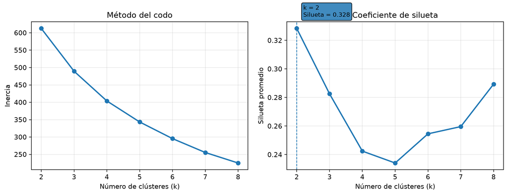

```python
# Gráfica de selección de k.
save_table(kmeans_results.metrics, TABLE_DIR / "metricas_kmeans.csv")
plot_kmeans_selection(
    kmeans_results.metrics,
    GRAPH_DIR / "seleccion_k_kmeans.png",
)
display(Image(filename=str(GRAPH_DIR / "seleccion_k_kmeans.png"), width=860))
```

**Análisis de resultados.** Entre los valores evaluados de `k = 2` a `k = 8`, la mayor silueta corresponde a `k = 2`, con un valor aproximado de **0.328**. Este resultado justifica seleccionar dos clústeres dentro del conjunto de alternativas probadas, pero no demuestra una separación fuerte: la estructura de agrupamiento es moderada y debe interpretarse como una simplificación descriptiva de los perfiles energéticos, no como una clasificación natural definitiva.

```
2026-07-12 12:17:12,988 | INFO | reporting | Tabla guardada: .\outputs\tablas\asignacion_paises_cluster.csv
2026-07-12 12:17:12,992 | INFO | reporting | Tabla guardada: .\outputs\tablas\perfiles_centroides.csv
2026-07-12 12:17:13,362 | INFO | visualization | Gráfica guardada: .\outputs\graficas\clusters_kmeans.png
```

|  | cluster | energy_per_capita | energy_per_gdp | fossil_share_energy | renewables_share_energy | nuclear_share_energy | coal_share_energy | oil_share_energy | gas_share_energy | low_carbon_share_energy | electricity_demand_per_capita |
| --- | --- | --- | --- | --- | --- | --- | --- | --- | --- | --- | --- |
| 0 | 0 | 39424.870 | 1.366 | 86.111 | 11.008 | 2.881 | 15.135 | 40.000 | 30.976 | 13.889 | 5556.469 |
| 1 | 1 | 60361.627 | 1.363 | 48.781 | 41.347 | 9.872 | 4.999 | 32.137 | 11.644 | 51.219 | 14046.935 |

|  | country | iso_code | year | cluster |
| --- | --- | --- | --- | --- |
| 0 | Algeria | DZA | 2022 | 0 |
| 1 | Argentina | ARG | 2022 | 0 |
| 2 | Australia | AUS | 2022 | 0 |
| 3 | Azerbaijan | AZE | 2022 | 0 |
| 4 | Bangladesh | BGD | 2022 | 0 |
| ... | ... | ... | ... | ... |
| 74 | New Zealand | NZL | 2022 | 1 |
| 75 | Norway | NOR | 2022 | 1 |
| 76 | Slovenia | SVN | 2022 | 1 |
| 77 | Sweden | SWE | 2022 | 1 |
| 78 | Switzerland | CHE | 2022 | 1 |

79 rows × 4 columns

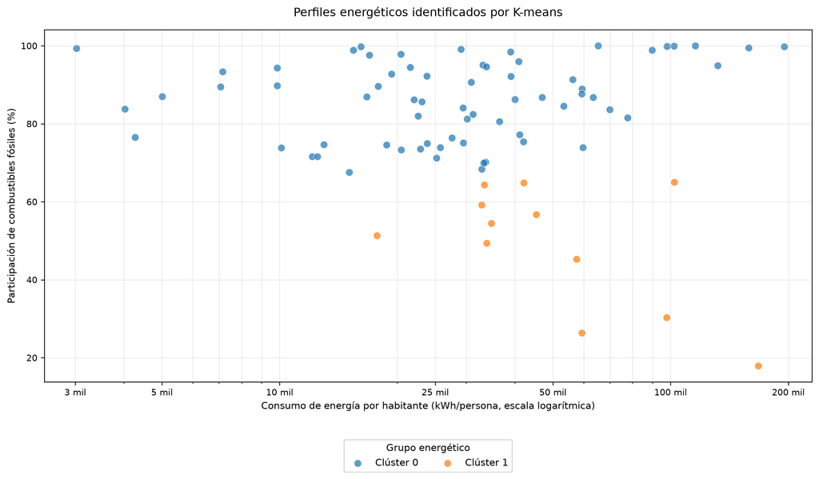

```python
# Asignación de países, perfiles y visualización de K-means.
country_clusters = build_country_clusters(kmeans_data, kmeans_results.labels)
cluster_profiles = build_cluster_profiles(
    kmeans_data,
    kmeans_results.labels,
    FEATURES,
)

save_table(country_clusters, TABLE_DIR / "asignacion_paises_cluster.csv")
save_table(cluster_profiles, TABLE_DIR / "perfiles_centroides.csv")

plot_kmeans_clusters(
    kmeans_data,
    kmeans_results.labels,
    GRAPH_DIR / "clusters_kmeans.png",
)

display(cluster_profiles.round(3))
display(country_clusters)
display(Image(filename=str(GRAPH_DIR / "clusters_kmeans.png"), width=800))
```

**Análisis de resultados.** Los centroides muestran diferencias claras en composición y consumo medio. El clúster 0 presenta aproximadamente **39,425 kWh por habitante**, **86.1 %** de participación fósil, **13.9 %** de participación baja en carbono y **5,556 kWh** de demanda eléctrica por habitante. El clúster 1 presenta aproximadamente **60,362 kWh por habitante**, **48.8 %** de participación fósil, **51.2 %** de participación baja en carbono y **14,047 kWh** de demanda eléctrica por habitante. En cambio, la intensidad energética media es prácticamente igual en ambos grupos: **1.366** frente a **1.363 kWh por dólar internacional**. Por ello, la separación de K-means está asociada principalmente con la composición de la matriz, el consumo por habitante y la demanda eléctrica, no con diferencias relevantes de intensidad energética. Estas diferencias describen asociaciones entre variables y no implican causalidad.

## 8. Modelo 2: PCA

PCA utiliza una segunda copia independiente del dataset. Su escalamiento no reutiliza el escalador ni la matriz transformada del modelo K-means. Así, cada modelo conserva su propio proceso de entrada, transformación y salida.

```python
# Dataset independiente para PCA.
pca_data = analytical_data.copy(deep=True)
print(f"Dataset PCA preparado: {pca_data.shape}")
```

```
Dataset PCA preparado: (79, 13)
```

```python
# Ejecución independiente de PCA.
pca_results = run_pca_analysis(pca_data, FEATURES)
display(pca_results.explained_variance.round(4))
```

```
2026-07-12 12:17:13,431 | INFO | modeling | Estandarización completada para 10 variables.
2026-07-12 12:17:13,434 | INFO | modeling | PCA ajustado: CP1 y CP2 explican 60.72% de la varianza.
```

|  | componente | varianza_explicada | varianza_acumulada |
| --- | --- | --- | --- |
| 0 | CP1 | 0.3711 | 0.3711 |
| 1 | CP2 | 0.2361 | 0.6072 |
| 2 | CP3 | 0.1431 | 0.7503 |
| 3 | CP4 | 0.1102 | 0.8605 |
| 4 | CP5 | 0.0847 | 0.9452 |
| 5 | CP6 | 0.0435 | 0.9887 |
| 6 | CP7 | 0.0113 | 1.0000 |
| 7 | CP8 | 0.0000 | 1.0000 |
| 8 | CP9 | 0.0000 | 1.0000 |
| 9 | CP10 | 0.0000 | 1.0000 |

```
2026-07-12 12:17:13,448 | INFO | reporting | Tabla guardada: .\outputs\tablas\varianza_explicada_pca.csv
2026-07-12 12:17:13,688 | INFO | visualization | Gráfica guardada: .\outputs\graficas\varianza_explicada_pca.png
```

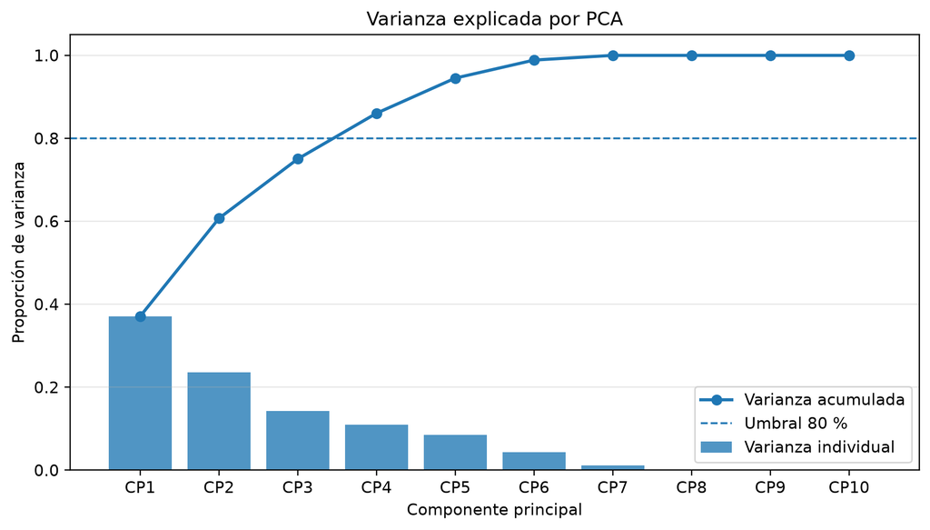

```python
# Varianza explicada de PCA.
save_table(
    pca_results.explained_variance,
    TABLE_DIR / "varianza_explicada_pca.csv",
)
plot_pca_variance(
    pca_results.explained_variance,
    GRAPH_DIR / "varianza_explicada_pca.png",
)
display(Image(filename=str(GRAPH_DIR / "varianza_explicada_pca.png"), width=780))
```

**Análisis de resultados.** CP1 explica **37.11 %** de la varianza y CP2 explica **23.61 %**; juntas conservan **60.72 %** de la variabilidad total. La varianza acumulada alcanza **75.03 %** con tres componentes y **86.05 %** con cuatro, por lo que se requieren cuatro componentes para superar el umbral de 80 %. En consecuencia, la proyección bidimensional es útil como resumen visual, pero omite aproximadamente **39.28 %** de la variación y no representa por completo la estructura multivariada de los países.

```
2026-07-12 12:17:13,710 | INFO | reporting | Tabla guardada: .\outputs\tablas\cargas_pca.csv
2026-07-12 12:17:14,108 | INFO | visualization | Gráfica guardada: .\outputs\graficas\cargas_pca.png
```

|  | variable | CP1 | CP2 | CP3 | CP4 | CP5 | CP6 | CP7 | CP8 | CP9 | CP10 |
| --- | --- | --- | --- | --- | --- | --- | --- | --- | --- | --- | --- |
| 0 | energy_per_capita | -0.1202 | 0.5249 | 0.1721 | 0.2521 | 0.3721 | -0.1939 | -0.6639 | 0.0000 | -0.0000 | -0.0000 |
| 1 | energy_per_gdp | -0.0091 | 0.5122 | -0.2258 | 0.0778 | -0.1247 | 0.8124 | 0.0705 | -0.0000 | 0.0000 | -0.0000 |
| 2 | fossil_share_energy | 0.5083 | 0.0726 | 0.0340 | 0.1331 | 0.0849 | -0.0375 | 0.0833 | 0.4446 | -0.0653 | 0.7071 |
| 3 | renewables_share_energy | -0.4699 | -0.0412 | 0.1194 | 0.0667 | -0.4202 | -0.0062 | -0.1250 | 0.6687 | 0.3455 | -0.0000 |
| 4 | nuclear_share_energy | -0.2168 | -0.0863 | -0.3363 | -0.4613 | 0.6928 | 0.1033 | 0.0668 | 0.3135 | 0.1620 | -0.0000 |
| 5 | coal_share_energy | 0.0689 | -0.2745 | -0.4911 | 0.6366 | 0.1216 | -0.0009 | -0.0467 | -0.1295 | 0.4895 | 0.0000 |
| 6 | oil_share_energy | 0.1058 | -0.2028 | 0.7196 | 0.0361 | 0.2692 | 0.3612 | 0.0661 | -0.1203 | 0.4547 | 0.0000 |
| 7 | gas_share_energy | 0.2880 | 0.4182 | -0.1093 | -0.4098 | -0.2181 | -0.2899 | 0.0570 | -0.1672 | 0.6320 | 0.0000 |
| 8 | low_carbon_share_energy | -0.5083 | -0.0726 | -0.0340 | -0.1331 | -0.0849 | 0.0375 | -0.0833 | -0.4446 | 0.0653 | 0.7071 |
| 9 | electricity_demand_per_capita | -0.3195 | 0.3887 | 0.1366 | 0.3212 | 0.2004 | -0.2726 | 0.7145 | -0.0000 | 0.0000 | 0.0000 |

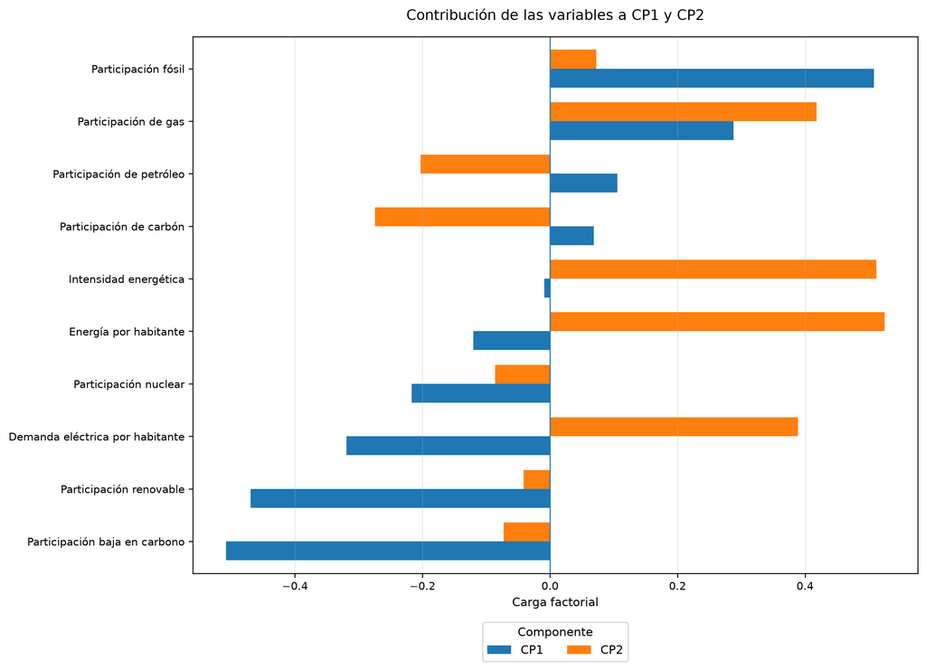

```python
# Cargas de las variables.
save_table(pca_results.loadings, TABLE_DIR / "cargas_pca.csv")
plot_pca_loadings(
    pca_results.loadings,
    GRAPH_DIR / "cargas_pca.png",
)
display(pca_results.loadings.round(4))
display(Image(filename=str(GRAPH_DIR / "cargas_pca.png"), width=820))
```

**Análisis de resultados.** De acuerdo con las cargas calculadas, en CP1 la participación fósil presenta la mayor carga positiva, aproximadamente **+0.508**, mientras que la participación baja en carbono y la participación renovable presentan cargas negativas de aproximadamente **−0.508** y **−0.470**, respectivamente. CP1 contrapone, por tanto, matrices con mayor dependencia fósil frente a matrices con mayor presencia renovable y baja en carbono. El signo de una componente principal es convencional y puede invertirse sin modificar la solución; lo relevante es la oposición entre las variables. En CP2 destacan energía por habitante (**+0.525**), intensidad energética (**+0.512**), participación del gas (**+0.418**) y demanda eléctrica por habitante (**+0.389**). CP2 representa principalmente una dimensión de nivel e intensidad del consumo, con una contribución adicional del gas.

```
2026-07-12 12:17:14,139 | INFO | reporting | Tabla guardada: .\outputs\tablas\puntuaciones_pca.csv
2026-07-12 12:17:14,551 | INFO | visualization | Gráfica guardada: .\outputs\graficas\proyeccion_pca.png
```

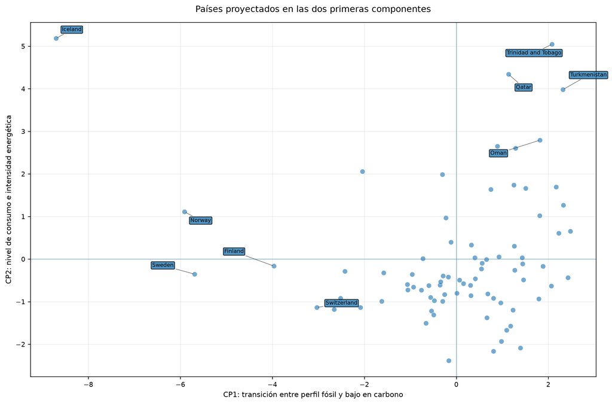

```python
# Proyección de países en las dos primeras componentes.
save_table(pca_results.scores, TABLE_DIR / "puntuaciones_pca.csv")
plot_pca_scores(
    pca_results.scores,
    GRAPH_DIR / "proyeccion_pca.png",
)
display(Image(filename=str(GRAPH_DIR / "proyeccion_pca.png"), width=780))
```

**Análisis de resultados.** La proyección en CP1 y CP2 permite identificar países alejados del centro, es decir, observaciones con combinaciones poco comunes en las dos dimensiones retenidas. Islandia, Noruega y Suecia se distinguen principalmente por su composición menos fósil, mientras que Qatar y Trinidad y Tobago destacan por niveles elevados de consumo, intensidad o demanda energética. Sin embargo, esta gráfica conserva solo **60.72 %** de la varianza total; por ello, la cercanía o distancia visual entre países debe interpretarse como un resumen parcial y no como una medida completa de similitud.

## 9. Interpretación energética de los resultados

### 9.1 Respuesta a la pregunta de investigación

El análisis identifica dos perfiles descriptivos dentro de la solución de K-means seleccionada:

- **Clúster 0: perfil fósil dominante.** Presenta menor consumo medio por habitante, menor demanda eléctrica y una participación fósil promedio alta.
- **Clúster 1: perfil de mayor consumo con más fuentes bajas en carbono.** Presenta mayor consumo y demanda eléctrica, junto con una matriz más diversificada hacia renovables, nuclear y otras fuentes bajas en carbono.

Los centroides cuantifican estas diferencias. El clúster 0 registra aproximadamente **39,425 kWh por habitante**, **86.1 %** de participación fósil y **5,556 kWh** de demanda eléctrica por habitante. El clúster 1 registra aproximadamente **60,362 kWh por habitante**, **48.8 %** de participación fósil, **51.2 %** de participación baja en carbono y **14,047 kWh** de demanda eléctrica por habitante.

La intensidad energética no diferencia de forma importante a los clústeres: sus promedios son prácticamente iguales, **1.366** y **1.363 kWh por dólar internacional**. Por tanto, la partición encontrada está asociada sobre todo con la composición de la matriz, el consumo por habitante y la demanda eléctrica.

Los casos de Qatar e Islandia ilustran por qué el consumo no debe interpretarse de manera aislada. Qatar presenta aproximadamente **195,336 kWh por habitante** y una participación fósil cercana a **99.81 %**. Islandia presenta aproximadamente **167,532 kWh por habitante**, pero solo **17.92 %** de participación fósil y **82.08 %** de participación baja en carbono. Ambos tienen consumos muy altos, pero matrices energéticas muy diferentes.

En el extremo de menor consumo, Bangladesh registra aproximadamente **3,024 kWh por habitante** y una participación fósil cercana a **99.31 %**. Este caso muestra que un consumo bajo tampoco implica necesariamente una matriz baja en carbono.

### 9.2 Variables que explican las diferencias

PCA organiza las diferencias entre países en dos dimensiones principales:

- **CP1: composición de la matriz energética.** La participación fósil tiene carga positiva (**+0.508**), mientras que la participación baja en carbono (**−0.508**) y la participación renovable (**−0.470**) tienen cargas opuestas. El signo es arbitrario; la interpretación sustantiva es la oposición entre ambos tipos de matriz.
- **CP2: nivel e intensidad del consumo.** Las mayores cargas corresponden a energía por habitante (**+0.525**), intensidad energética (**+0.512**), participación del gas (**+0.418**) y demanda eléctrica por habitante (**+0.389**).

CP1 y CP2 explican conjuntamente **60.72 %** de la variabilidad. Cuatro componentes alcanzan **86.05 %**, de modo que la representación en dos dimensiones es informativa, pero incompleta.

En síntesis, K-means identifica dos perfiles descriptivos, mientras PCA muestra que las principales diferencias se relacionan con la composición fósil frente a baja en carbono y con el nivel e intensidad del consumo energético.

```python
# Interpretación automática basada en las métricas calculadas.
selected_row = kmeans_results.metrics.loc[
    kmeans_results.metrics["k"] == kmeans_results.selected_k
].iloc[0]

explained_two = float(
    pca_results.explained_variance.loc[1, "varianza_acumulada"]
)
components_80 = int(
    (pca_results.explained_variance["varianza_acumulada"] < 0.80).sum() + 1
)

interpretation = summarize_results(
    kmeans_results.selected_k,
    float(selected_row["silhouette"]),
    explained_two,
    components_80,
)
print(interpretation)
```

[output not shown]

```python
# Variables con mayor contribución absoluta en CP1 y CP2.
loading_rank = pca_results.loadings.copy()
loading_rank["abs_CP1"] = loading_rank["CP1"].abs()
loading_rank["abs_CP2"] = loading_rank["CP2"].abs()

top_cp1 = loading_rank.nlargest(4, "abs_CP1")[["variable", "CP1"]]
top_cp2 = loading_rank.nlargest(4, "abs_CP2")[["variable", "CP2"]]

print("Variables dominantes en CP1:")
display(top_cp1.round(4))
print("Variables dominantes en CP2:")
display(top_cp2.round(4))
```

```
Variables dominantes en CP1:
```

|  | variable | CP1 |
| --- | --- | --- |
| 2 | fossil_share_energy | 0.5083 |
| 8 | low_carbon_share_energy | -0.5083 |
| 3 | renewables_share_energy | -0.4699 |
| 9 | electricity_demand_per_capita | -0.3195 |

```
Variables dominantes en CP2:
```

|  | variable | CP2 |
| --- | --- | --- |
| 0 | energy_per_capita | 0.5249 |
| 1 | energy_per_gdp | 0.5122 |
| 7 | gas_share_energy | 0.4182 |
| 9 | electricity_demand_per_capita | 0.3887 |

## 10. Comparación de los modelos

K-means y PCA responden preguntas complementarias, pero sus resultados no deben confundirse.

| Aspecto | K-means | PCA |
| --- | --- | --- |
| Pregunta principal | ¿Qué observaciones presentan perfiles multivariados semejantes? | ¿Qué combinaciones de variables explican la mayor variación? |
| Resultado | Dos clústeres seleccionados por la mayor silueta entre `k = 2` y `k = 8` | Componentes continuas y ortogonales |
| Evidencia principal | Silueta aproximada de **0.328** y centroides de los grupos | **60.72 %** con CP1 y CP2; **86.05 %** con cuatro componentes |
| Interpretación | Perfil fósil dominante frente a perfil de mayor consumo con más fuentes bajas en carbono | Composición de la matriz en CP1 y nivel e intensidad del consumo en CP2 |
| Limitación principal | La separación es moderada y depende de las variables, el escalamiento y el rango de `k` evaluado | La proyección en dos componentes omite **39.28 %** de la varianza |

K-means resume la muestra mediante dos perfiles. El primer grupo tiene mayor dependencia fósil y menor demanda eléctrica media. El segundo presenta mayor consumo y demanda eléctrica, pero también una participación mucho mayor de fuentes bajas en carbono. La intensidad energética media, sin embargo, es prácticamente igual entre los dos clústeres, por lo que no constituye el principal factor de separación del agrupamiento.

PCA complementa esta descripción. CP1 contrapone participación fósil frente a participación renovable y baja en carbono. CP2 está dominada por consumo por habitante, intensidad energética, demanda eléctrica y gas. Esta estructura ayuda a explicar por qué países con consumos altos, como Qatar e Islandia, pueden diferir fuertemente en la composición de su matriz.

No debe afirmarse que PCA “valida” los clústeres, porque PCA no evalúa la calidad de K-means y K-means no determina la interpretación de las componentes. La coincidencia entre ambos modelos es sustantiva: los dos señalan que la composición de las fuentes y el nivel de consumo son dimensiones relevantes del perfil energético.

La conclusión comparativa es:

> **K-means resume similitudes mediante grupos; PCA identifica las direcciones de variación que ayudan a interpretar esas similitudes y diferencias.**

```python
# Tabla comparativa final.
comparison_table = build_model_comparison(
    selected_k=kmeans_results.selected_k,
    silhouette=float(selected_row["silhouette"]),
    explained_two=explained_two,
    components_80=components_80,
)
save_table(comparison_table, TABLE_DIR / "comparacion_modelos.csv")
display(comparison_table)
```

```
2026-07-12 12:17:14,632 | INFO | reporting | Tabla guardada: .\outputs\tablas\comparacion_modelos.csv
```

|  | modelo | objetivo | salida_principal | criterio_prueba | resultado_clave |
| --- | --- | --- | --- | --- | --- |
| 0 | K-means | Agrupar países por similitud energética | 2 clústeres | Inercia y silueta | Silueta = 0.328 |
| 1 | PCA | Reducir dimensionalidad y explicar variación | Componentes principales | Varianza explicada y cargas | CP1+CP2 = 60.7%; 4 componentes alcanzan 80% |

## 11. Conclusiones

### 11.1 Respuesta final a la pregunta de investigación

Dentro de los valores de `k` evaluados, K-means seleccionó dos clústeres porque `k = 2` obtuvo la mayor silueta promedio, aproximadamente **0.328**. Este valor respalda una partición descriptiva, aunque la separación entre grupos es moderada.

Los perfiles identificados son:

1. **Perfil fósil dominante:** aproximadamente **39,425 kWh por habitante**, **86.1 %** de participación fósil, **13.9 %** de participación baja en carbono y **5,556 kWh** de demanda eléctrica por habitante.
2. **Perfil de mayor consumo con más fuentes bajas en carbono:** aproximadamente **60,362 kWh por habitante**, **48.8 %** de participación fósil, **51.2 %** de participación baja en carbono y **14,047 kWh** de demanda eléctrica por habitante.

La intensidad energética promedio es casi idéntica entre ambos grupos, por lo que no es un discriminante importante de la solución de K-means.

PCA indica que las principales diferencias se relacionan con:

- la oposición entre participación fósil y participación renovable o baja en carbono;
- el consumo de energía por habitante;
- la intensidad energética;
- la demanda eléctrica por habitante;
- la participación del gas.

### 11.2 Hallazgos sustentados por los datos

1. CP1 explica **37.11 %** y CP2 **23.61 %**; juntas explican **60.72 %** de la varianza.
2. Se requieren cuatro componentes para alcanzar **86.05 %** de varianza acumulada y superar el umbral de 80 %.
3. Qatar e Islandia muestran que un consumo alto puede coexistir con matrices opuestas: Qatar tiene aproximadamente **99.81 %** de participación fósil, mientras Islandia tiene aproximadamente **82.08 %** de participación baja en carbono.
4. Bangladesh muestra que un consumo bajo no implica necesariamente una matriz baja en carbono, ya que registra aproximadamente **99.31 %** de participación fósil.
5. Las cargas de CP1 reflejan una oposición entre participación fósil (**+0.508**) y participación baja en carbono (**−0.508**) o renovable (**−0.470**).
6. Las mayores cargas de CP2 corresponden a energía por habitante (**+0.525**), intensidad energética (**+0.512**), gas (**+0.418**) y demanda eléctrica por habitante (**+0.389**).

### 11.3 Alcance y limitaciones

Los resultados son descriptivos para 2022 y no establecen causalidad. Los números de clúster son etiquetas arbitrarias y podrían intercambiarse sin alterar la partición. La solución depende de la selección de variables, la estandarización, la exclusión de casos incompletos y el rango de `k` evaluado. Además, CP1 y CP2 omiten **39.28 %** de la varianza total, por lo que la gráfica bidimensional no representa toda la información disponible.

En consecuencia, la evidencia permite afirmar que la composición de la matriz y el nivel de consumo diferencian los perfiles energéticos observados, pero no permite formular juicios causales, normativos ni universales sobre los países.

## 12. Referencias en formato APA

Géron, A. (2019). *Hands-on machine learning with Scikit-Learn, Keras, and TensorFlow* (2.ª ed.). O’Reilly Media.

James, G., Witten, D., Hastie, T., & Tibshirani, R. (2013). *An introduction to statistical learning: With applications in R*. Springer.

Our World in Data. (2026). *Energy*. https://ourworldindata.org/energy

Our World in Data. (2026). *OWID energy data* [Conjunto de datos]. GitHub. https://github.com/owid/energy-data

Pedregosa, F., Varoquaux, G., Gramfort, A., et al. (2011). Scikit-learn: Machine learning in Python. *Journal of Machine Learning Research, 12*, 2825-2830.